# Prediction of Term Deposit Subscription

Srinivasa V

11th Nov 2018

**NOTE** Before starting this assignment please remember to clear your environment, you can do that by running the following code chunk

```r
rm(list=ls(all=TRUE))
```

# Agenda

- Get the data
- Data Pre-processing
- Build a model
- Predictions
- Communication

# Reading & Understanding the Data

## Data Domain and Format

- The data given to you will be in a .txt file.
- The values on each line of the dataset are separated by “;”
- Read in the data using the “read.table()” function.

## Read the Data

Make sure the dataset is located in your current working directory, else you can change your working directory using the “setwd()” function.

```r
bank_data <- read.table("bank.txt", header=T, sep=";")
```

## Data Description

- The dataset is from a bank, using which we have to predict whether the subject subscribes to a term deposit or not
- The dataset has the following attributes:

1 - age (numeric)

2 - job : type of job (categorical: “admin.”,“unknown”,“unemployed”,“management”,“housemaid”,“entrepreneur”,“student”, “blue-collar”,“self-employed”,“retired”,“technician”,“services”)

3 - marital : marital status (categorical: “married”,“divorced”,“single”; note: “divorced” means divorced or widowed)

4 - education (categorical: “unknown”,“secondary”,“primary”,“tertiary”)

5 - default: has credit in default? (binary: “yes”,“no”)

6 - balance: average yearly balance, in euros (numeric)

7 - housing: has housing loan? (binary: “yes”,“no”)

8 - loan: has personal loan? (binary: “yes”,“no”)

9 - contact: contact communication type (categorical: “unknown”,“telephone”,“cellular”)

10 - day: last contact day of the month (numeric)

11 - month: last contact month of year (categorical: “jan”, “feb”, “mar”, …, “nov”, “dec”)

12 - duration: last contact duration, in seconds (numeric)

13 - campaign: number of contacts performed during this campaign and for this client (numeric, includes last contact)

14 - pdays: number of days that passed by after the client was last contacted from a previous campaign (numeric, -1 means client was not previously contacted)

15 - previous: number of contacts performed before this campaign and for this client (numeric)

16 - poutcome: outcome of the previous marketing campaign (categorical: “unknown”,“other”,“failure”,“success”)

**Response Variable (desired target):**

17 - y - has the client subscribed to a **term deposit?** (binary: “yes”,“no”)

## Understand the data

- Use the str() function to get the dimensions and types of attributes in the dataset
- The dataset has 4521 observations and 17 variables

```r
str(bank_data)
```

```
## 'data.frame':    4521 obs. of  17 variables:
##  $ age      : int  30 33 35 30 59 35 36 39 41 43 ...
##  $ job      : Factor w/ 12 levels "admin.","blue-collar",..: 11 8 5 5 2 5 7 10 3 8 ...
##  $ marital  : Factor w/ 3 levels "divorced","married",..: 2 2 3 2 2 3 2 2 2 2 ...
##  $ education: Factor w/ 4 levels "primary","secondary",..: 1 2 3 3 2 3 3 2 3 1 ...
##  $ default  : Factor w/ 2 levels "no","yes": 1 1 1 1 1 1 1 1 1 1 ...
##  $ balance  : int  1787 4789 1350 1476 0 747 307 147 221 -88 ...
##  $ housing  : Factor w/ 2 levels "no","yes": 1 2 2 2 2 1 2 2 2 2 ...
##  $ loan     : Factor w/ 2 levels "no","yes": 1 2 1 2 1 1 1 1 1 2 ...
##  $ contact  : Factor w/ 3 levels "cellular","telephone",..: 1 1 1 3 3 1 1 1 3 1 ...
##  $ day      : int  19 11 16 3 5 23 14 6 14 17 ...
##  $ month    : Factor w/ 12 levels "apr","aug","dec",..: 11 9 1 7 9 4 9 9 9 1 ...
##  $ duration : int  79 220 185 199 226 141 341 151 57 313 ...
##  $ campaign : int  1 1 1 4 1 2 1 2 2 1 ...
##  $ pdays    : int  -1 339 330 -1 -1 176 330 -1 -1 147 ...
##  $ previous : int  0 4 1 0 0 3 2 0 0 2 ...
##  $ poutcome : Factor w/ 4 levels "failure","other",..: 4 1 1 4 4 1 2 4 4 1 ...
##  $ y        : Factor w/ 2 levels "no","yes": 1 1 1 1 1 1 1 1 1 1 ...
```

- Use the summary() function to understand the distribution of variables in the dataset

```r
summary(bank_data)
```

```
##       age                 job          marital         education
##  Min.   :19.00   management :969   divorced: 528   primary  : 678
##  1st Qu.:33.00   blue-collar:946   married :2797   secondary:2306
##  Median :39.00   technician :768   single  :1196   tertiary :1350
##  Mean   :41.17   admin.     :478                   unknown  : 187
##  3rd Qu.:49.00   services   :417
##  Max.   :87.00   retired    :230
##                  (Other)    :713
##  default       balance      housing     loan           contact
##  no :4445   Min.   :-3313   no :1962   no :3830   cellular :2896
##  yes:  76   1st Qu.:   69   yes:2559   yes: 691   telephone: 301
##             Median :  444                         unknown  :1324
##             Mean   : 1423
##             3rd Qu.: 1480
##             Max.   :71188
##
##       day            month         duration       campaign
##  Min.   : 1.00   may    :1398   Min.   :   4   Min.   : 1.000
##  1st Qu.: 9.00   jul    : 706   1st Qu.: 104   1st Qu.: 1.000
##  Median :16.00   aug    : 633   Median : 185   Median : 2.000
##  Mean   :15.92   jun    : 531   Mean   : 264   Mean   : 2.794
##  3rd Qu.:21.00   nov    : 389   3rd Qu.: 329   3rd Qu.: 3.000
##  Max.   :31.00   apr    : 293   Max.   :3025   Max.   :50.000
##                  (Other): 571
##      pdays           previous          poutcome      y
##  Min.   : -1.00   Min.   : 0.0000   failure: 490   no :4000
##  1st Qu.: -1.00   1st Qu.: 0.0000   other  : 197   yes: 521
##  Median : -1.00   Median : 0.0000   success: 129
##  Mean   : 39.77   Mean   : 0.5426   unknown:3705
##  3rd Qu.: -1.00   3rd Qu.: 0.0000
##  Max.   :871.00   Max.   :25.0000
##
```

- Use the head() and tail() functions to get a look at the data

```r
head(bank_data)
```

```
##   age         job marital education default balance housing loan  contact
## 1  30  unemployed married   primary      no    1787      no   no cellular
## 2  33    services married secondary      no    4789     yes  yes cellular
## 3  35  management  single  tertiary      no    1350     yes   no cellular
## 4  30  management married  tertiary      no    1476     yes  yes  unknown
## 5  59 blue-collar married secondary      no       0     yes   no  unknown
## 6  35  management  single  tertiary      no     747      no   no cellular
##   day month duration campaign pdays previous poutcome  y
## 1  19   oct       79        1    -1        0  unknown no
## 2  11   may      220        1   339        4  failure no
## 3  16   apr      185        1   330        1  failure no
## 4   3   jun      199        4    -1        0  unknown no
## 5   5   may      226        1    -1        0  unknown no
## 6  23   feb      141        2   176        3  failure no
```

```r
tail(bank_data)
```

```
##      age           job marital education default balance housing loan
## 4516  32      services  single secondary      no     473     yes   no
## 4517  33      services married secondary      no    -333     yes   no
## 4518  57 self-employed married  tertiary     yes   -3313     yes  yes
## 4519  57    technician married secondary      no     295      no   no
## 4520  28   blue-collar married secondary      no    1137      no   no
## 4521  44  entrepreneur  single  tertiary      no    1136     yes  yes
##       contact day month duration campaign pdays previous poutcome  y
## 4516 cellular   7   jul      624        5    -1        0  unknown no
## 4517 cellular  30   jul      329        5    -1        0  unknown no
## 4518  unknown   9   may      153        1    -1        0  unknown no
## 4519 cellular  19   aug      151       11    -1        0  unknown no
## 4520 cellular   6   feb      129        4   211        3    other no
## 4521 cellular   3   apr      345        2   249        7    other no
```

# Data Pre-processing

## Missing Values

- Check the number of missing values in the data frame

```r
sum(is.na(bank_data))
```

```
## [1] 0
```

## Train/Test Split

- Split the data 70/30 into train and test sets by using **Stratified Sampling** and setting the seed as “786”
- Split the data using stratified sampling, we can do that by using the createDataPartition() function from the caret package

```r
library(caret)
set.seed(786)

# The argument "y" to the createDataPartition() function is the response variable

# The argument "p" is the percentage of data that goes to training

# The argument "list" should be input a boolean (T or F). Remember to put list = F, else the output is going to  be a list and your data can't be subsetted with it

train_rows <- createDataPartition(bank_data$y, p = 0.7, list = F)

train_data <- bank_data[train_rows, ]

test_data <- bank_data[-train_rows, ]
```

```r
dim(train_rows)
```

```
## [1] 3165    1
```

```r
str(train_data)
```

```
## 'data.frame':    3165 obs. of  17 variables:
##  $ age      : int  30 33 35 30 36 43 39 31 56 37 ...
##  $ job      : Factor w/ 12 levels "admin.","blue-collar",..: 11 8 5 5 7 8 8 2 10 1 ...
##  $ marital  : Factor w/ 3 levels "divorced","married",..: 2 2 3 2 2 2 2 2 2 3 ...
##  $ education: Factor w/ 4 levels "primary","secondary",..: 1 2 3 3 3 1 2 2 2 3 ...
##  $ default  : Factor w/ 2 levels "no","yes": 1 1 1 1 1 1 1 1 1 1 ...
##  $ balance  : int  1787 4789 1350 1476 307 -88 9374 360 4073 2317 ...
##  $ housing  : Factor w/ 2 levels "no","yes": 1 2 2 2 2 2 2 2 1 2 ...
##  $ loan     : Factor w/ 2 levels "no","yes": 1 2 1 2 1 2 1 2 1 1 ...
##  $ contact  : Factor w/ 3 levels "cellular","telephone",..: 1 1 1 3 1 1 3 1 1 1 ...
##  $ day      : int  19 11 16 3 14 17 20 29 27 20 ...
##  $ month    : Factor w/ 12 levels "apr","aug","dec",..: 11 9 1 7 9 1 9 5 2 1 ...
##  $ duration : int  79 220 185 199 341 313 273 89 239 114 ...
##  $ campaign : int  1 1 1 4 1 1 1 1 5 1 ...
##  $ pdays    : int  -1 339 330 -1 330 147 -1 241 -1 152 ...
##  $ previous : int  0 4 1 0 2 2 0 1 0 2 ...
##  $ poutcome : Factor w/ 4 levels "failure","other",..: 4 1 1 4 2 1 4 1 4 1 ...
##  $ y        : Factor w/ 2 levels "no","yes": 1 1 1 1 1 1 1 1 1 1 ...
```

# Build a model

## Basic Logistic Regression Model

- Use the glm() function to build a basic model
- Build a model using all the variables, excluding the response variable, in the dataset

```r
log_reg <- glm(y~., data = train_data, family = binomial)
```

- Get the summary of the model and understand the output

```r
summary(log_reg)
```

```
##
## Call:
## glm(formula = y ~ ., family = binomial, data = train_data)
##
## Deviance Residuals:
##     Min       1Q   Median       3Q      Max
## -4.1621  -0.3705  -0.2429  -0.1382   2.8829
##
## Coefficients:
##                      Estimate Std. Error z value Pr(>|z|)
## (Intercept)        -2.848e+00  7.349e-01  -3.876 0.000106 ***
## age                 7.836e-04  8.607e-03   0.091 0.927464
## jobblue-collar     -6.363e-01  2.939e-01  -2.165 0.030366 *
## jobentrepreneur    -2.794e-01  4.464e-01  -0.626 0.531389
## jobhousemaid       -6.548e-01  5.007e-01  -1.308 0.190990
## jobmanagement      -2.667e-01  2.901e-01  -0.920 0.357810
## jobretired          5.161e-01  3.644e-01   1.416 0.156745
## jobself-employed   -5.447e-01  4.300e-01  -1.267 0.205214
## jobservices        -4.210e-01  3.280e-01  -1.283 0.199327
## jobstudent         -2.476e-01  4.774e-01  -0.519 0.604106
## jobtechnician      -6.178e-01  2.808e-01  -2.200 0.027810 *
## jobunemployed      -8.257e-01  5.100e-01  -1.619 0.105450
## jobunknown          5.986e-01  6.741e-01   0.888 0.374546
## maritalmarried     -5.847e-01  2.082e-01  -2.808 0.004987 **
## maritalsingle      -3.822e-01  2.466e-01  -1.550 0.121226
## educationsecondary  1.443e-01  2.477e-01   0.583 0.560188
## educationtertiary   4.563e-01  2.843e-01   1.605 0.108531
## educationunknown   -1.869e-01  4.305e-01  -0.434 0.664160
## defaultyes         -1.239e-01  6.946e-01  -0.178 0.858369
## balance             2.785e-05  2.173e-05   1.282 0.199983
## housingyes         -3.035e-01  1.685e-01  -1.801 0.071738 .
## loanyes            -5.923e-01  2.489e-01  -2.380 0.017310 *
## contacttelephone   -1.495e-01  2.784e-01  -0.537 0.591176
## contactunknown     -1.610e+00  2.866e-01  -5.617 1.95e-08 ***
## day                 1.452e-02  1.018e-02   1.427 0.153524
## monthaug           -1.274e-01  2.973e-01  -0.429 0.668252
## monthdec            5.434e-01  7.986e-01   0.680 0.496202
## monthfeb            2.482e-01  3.531e-01   0.703 0.482142
## monthjan           -1.294e+00  4.979e-01  -2.599 0.009358 **
## monthjul           -6.075e-01  2.968e-01  -2.047 0.040651 *
```

[output cut: 8 more lines]

```
## pdays               1.166e-03  1.149e-03   1.015 0.310042
## previous            1.901e-02  4.488e-02   0.424 0.671912
## poutcomeother       5.785e-01  3.122e-01   1.853 0.063928 .
## poutcomesuccess     2.573e+00  3.474e-01   7.406 1.30e-13 ***
## poutcomeunknown     1.452e-01  3.779e-01   0.384 0.700908
## ---
## Signif. codes:  0 '***' 0.001 '**' 0.01 '*' 0.05 '.' 0.1 ' ' 1
##
## (Dispersion parameter for binomial family taken to be 1)
##
##     Null deviance: 2263.0  on 3164  degrees of freedom
## Residual deviance: 1464.5  on 3122  degrees of freedom
## AIC: 1550.5
##
## Number of Fisher Scoring iterations: 6
```

- Calcuating the Deviance Residuals

```r
Devaince_residuals = residuals(log_reg, "deviance")
summary(Devaince_residuals)
```

```
##    Min. 1st Qu.  Median    Mean 3rd Qu.    Max.
## -4.1621 -0.3705 -0.2429 -0.1388 -0.1382  2.8829
```

- Calculating the log likeli hood

```r
logLik(log_reg)
```

```
## 'log Lik.' -732.2353 (df=43)
```

# ROC

## Predicted Values are between 0 and 1

- The predict() function on the “glm” object of “binomial” family gives a probability score between 0 and 1, NOT the original levels (0 and 1) of the response variable
- Hence we must first choose a cutoff point for getting to the original levels of the response variables
- To choose the cutoff point we will use the train data, as test data should not be used to make any decisions regarding the model

## Creating an ROC plot

**Steps to create an ROC plot :**

1. Get a list of predictions (probability scores) using the predict() function

```r
# Use the argument 'type = "response"' in the predict function to get a list of predictions between 0 and 1

# By default if no dataset is mentioned, training data is used

prob_train <- predict(log_reg, type = "response")

prob_train[1:6]
```

```
##          1          2          3          4          7         10
## 0.07873379 0.03490491 0.13129179 0.01570341 0.17692036 0.05087197
```

2. Using the ROCR package create a “prediction()” object

```r
library(ROCR)
# The prediction object takes the probability scores and the original levels for theses data as input

pred <- prediction(prob_train, train_data$y)

# The prediction object contains a list of predictions (probability scores), original class labels, cutoffs, false positives, true positives, true negatives, false negatives, No. of positive predictions and No. of negative predictions corresponding to these cutoffs. Class distribution in the dataset.
```

```r
pred
```

[output not shown]

[output cut: 4062 more lines]

[output not shown]

3. Extract performance measures (True Positive Rate and False Positive Rate) using the “performance()” function from the ROCR package

```r
# The performance() function from the ROCR package helps us extract metrics such as True positive rate, False positive rate etc. from the prediction object, we created above.

# Two measures (y-axis = tpr, x-axis = fpr) are extracted

perf <- performance(pred, measure="tpr", x.measure="fpr")
```

4. Plot the ROC curve using the extracted performance measures (TPR and FPR)

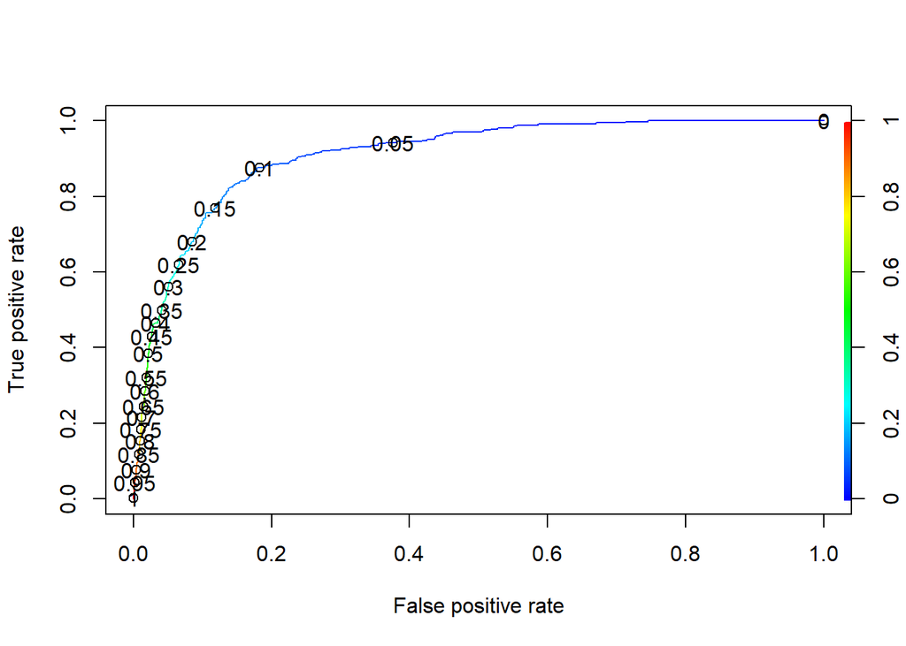

```r
plot(perf, col=rainbow(10), colorize=T, print.cutoffs.at=seq(0,1,0.05))
```

- Extract the AUC score of the ROC curve and store it in a variable named “auc”
- Use the performance() function on the prediction object created above using the ROCR package, to extract the AUC score

```r
perf_auc <- performance(pred, measure="auc")

# Access the auc score from the performance object

auc <- perf_auc@y.values[[1]]

print(auc)
```

```
## [1] 0.9101438
```

## Choose a Cutoff Value

- Based on the trade off between TPR and FPR depending on the business domain, a call on the cutoff has to be made.
- A cutoff of 0.1 can be chosen

## Predictions on test data

- After choosing a cutoff value of 0.1, let’s predict the class labels on the test data using our model

```r
prob_test <- predict(log_reg, test_data, type = "response")

preds_test <- ifelse(prob_test > 0.1, "yes", "no")
```

# Evaluation Metrics for classification

## Manual Computation

### Confusion Matrix

- Create a confusion matrix using the table() function

```r
test_data_labs <- test_data$y

conf_matrix <- table(test_data_labs, preds_test)

print(conf_matrix)
```

```
##               preds_test
## test_data_labs  no yes
##            no  956 244
##            yes  32 124
```

### Specificity

- The Proportion of correctly identified negatives by the test/model.

$${Specificity} = \frac{Number~of~True~Negatives}{Number~of~True~Negatives + Number~of~False~Positives}$$

```r
specificity <- conf_matrix[1, 1]/sum(conf_matrix[1, ])

print(specificity)
```

```
## [1] 0.7966667
```

### Sensitivity

- The Proportion of correctly identified positives by the test/model.

$${Sensitivity} = \frac{Number~of~True~Positives}{Number~of~True~Positives + Number~of~False~Negatives}$$

```r
sensitivity <- conf_matrix[2, 2]/sum(conf_matrix[2, ])

print(sensitivity)
```

```
## [1] 0.7948718
```

### Accuracy

- The Proportion of correctly identified psotivies/negatives in the entire population by the test/model

$${Accuracy} = \frac{Number~of~True~Positives +Number~of~True~Negatives}{Number~Of~Subjects~in~the~Population}$$

```r
accuracy <- sum(diag(conf_matrix))/sum(conf_matrix)

print(accuracy)
```

```
## [1] 0.7964602
```

## Automated Computation through Caret

- Evaluation metrics for classification can be accessed through the “confusionMatrix()” function from the caret package

```r
#library(caret)

# Using the argument "Positive", we can get the evaluation metrics according to our positive referene level

#confusionMatrix(preds_test, test_data$y, positive = "yes")
```